# EALS Study 1 Analysis: Puzzle Choice

Kat Adams Shannon

2024-30-01

# Project Overview

Study 1 of the EALS project is composed of two data collection efforts:

- V1. Puzzles visible
- V2. Puzzles obscured

Preregistation available for V1: AsPredicted #89040 and V2: AsPredicted #103468

# Analytic goals

1. First we will run a logistic regression in the form of choice of puzzle harder ~ condition (reliable/unreliable help).
2. We will also generate Bayes factors for interpretation of the evidence of our hypothesis of a condition effect and for sequential sampling.
- The sampling stopping criteria is: We will test an initial sample of 10 children in each condition, and then evaluate the Bayes Factor on the hypothesis of a negative condition effect (unreliable experimenter -> lower choice of hard puzzle) after each day of testing. We will stop testing if either a BF > 10 in favor of the hypothesis of a negative condition effect, a BF > 3 against the hypothesis, or at an N=30/condition (N=60 total). Note, we report the final N = 60 here for the Cog Sci 24 paper analyses.
3. Next, we will run a followup regression including a main effect of age (in months, centered) and an interaction of age and condition.

This analysis is repeated below first for V1 (puzzles visible) and then for V2 (puzzles obscured)

Finally, in post-hoc, non-preregistered analyses, we pool the datasets across V1 and V2 to look at condition effects and age-by-condition interaction.

## Experiment 1 (Puzzles Visible, N = 60)

We begin with the preregistered analyses for V1 (puzzles visible) N=60

#### How many participants chose harder/larger-reward puzzle per condition in V1 (N=60)?

```
## # A tibble: 4 × 3
##   condition  puzzle_harder     n
##   <chr>              <dbl> <int>
## 1 Reliable               0     8
## 2 Reliable               1    22
## 3 Unreliable             0    16
## 4 Unreliable             1    14
```

#### Mean of choice harder/larger-reward puzzle per condition in V1 (N=60)

```
## # A tibble: 2 × 2
##   condition  mean_harder
##   <chr>            <dbl>
## 1 Reliable         0.733
## 2 Unreliable       0.467
```

#### Logistic regression in V1 (N=60)

Here we are predicting harder/larger reward puzzle choice with reliable as reference group (so asking if there is a negative effect of unreliable on choice harder puzzle, as prereg)

```
##
## Call:
## glm(formula = puzzle_harder ~ condition, family = "binomial",
##     data = eals1_v1_n60_df)
##
## Deviance Residuals:
##     Min       1Q   Median       3Q      Max
## -1.6259  -1.1213   0.7876   0.7876   1.2346
##
## Coefficients:
##                     Estimate Std. Error z value Pr(>|z|)
## (Intercept)           1.0116     0.4129   2.450   0.0143 *
## conditionUnreliable  -1.1451     0.5517  -2.076   0.0379 *
## ---
## Signif. codes:  0 '***' 0.001 '**' 0.01 '*' 0.05 '.' 0.1 ' ' 1
##
## (Dispersion parameter for binomial family taken to be 1)
##
##     Null deviance: 80.761  on 59  degrees of freedom
## Residual deviance: 76.250  on 58  degrees of freedom
## AIC: 80.25
##
## Number of Fisher Scoring iterations: 4
```

```
##         (Intercept) conditionUnreliable
##                1.01               -1.15
```

Next, we will compute the odds ratio for effect of unreliable:

```
##         (Intercept) conditionUnreliable
##                2.75                0.32
```

In V1 (N=60), compared to the reliable condition, those children in the unreliable condition have ~.32 times odds (harder to conceptualize because fraction) of choosing the harder/larger-reward puzzle.

We can also flip so unreliable is reference group, which makes the odds ratios easier to interpret (i.e., odds ratio will be >1 for effect of reliable on choice of puzzle harder).

#### Logistic regression predicting harder/larger reward puzzle choice - flipped with unreliable as reference group - in V1 (N=60)

```
##
## Call:
## glm(formula = puzzle_harder ~ relevel(as.factor(condition), ref = "Unreliable"),
##     family = "binomial", data = eals1_v1_n60_df)
##
## Deviance Residuals:
##     Min       1Q   Median       3Q      Max
## -1.6259  -1.1213   0.7876   0.7876   1.2346
##
## Coefficients:
##                                                           Estimate Std. Error
## (Intercept)                                                -0.1335     0.3660
## relevel(as.factor(condition), ref = "Unreliable")Reliable   1.1451     0.5517
##                                                           z value Pr(>|z|)
## (Intercept)                                                -0.365   0.7152
## relevel(as.factor(condition), ref = "Unreliable")Reliable   2.076   0.0379 *
## ---
## Signif. codes:  0 '***' 0.001 '**' 0.01 '*' 0.05 '.' 0.1 ' ' 1
##
## (Dispersion parameter for binomial family taken to be 1)
##
##     Null deviance: 80.761  on 59  degrees of freedom
## Residual deviance: 76.250  on 58  degrees of freedom
## AIC: 80.25
##
## Number of Fisher Scoring iterations: 4
```

```
##                                               (Intercept)
##                                                     -0.13
## relevel(as.factor(condition), ref = "Unreliable")Reliable
##                                                      1.15
```

Next, we will compute the odds ratio for effect of reliable:

```
##                                               (Intercept)
##                                                      0.88
## relevel(as.factor(condition), ref = "Unreliable")Reliable
##                                                      3.14
```

In V1 (N=60), compared to unreliable, those children in the reliable condition have 3.14 times higher odds of choosing harder/larger reward puzzle (same thing, so say it this way is easier to understand = ~1/.32)

Since this is easier to interpret, we will report the flipped model odds ratio in the cog sci paper.

#### 95% confidence intervals of flipped model in V1 (N=60)

```
##                                                           2.5 % 97.5 %
## (Intercept)                                                0.42   1.80
## relevel(as.factor(condition), ref = "Unreliable")Reliable  1.09   9.64
```

Next, we will compute the Bayes factor on the original (non-flipped) logistic regression with reliable as the reference group, because this is our pre-registered approach.

#### Computing Bayes factor on logistic regression in V1 (N=60)

```
## Call:
## BF.glm(x = eals1_mod_v1_n60, hypothesis = "condition < 0; condition = 0",
##     complement = FALSE)
##
## Bayesian hypothesis test
## Type: exploratory
## Object: glm
## Parameter: general parameters
## Method: adjusted fractional Bayes factors using Gaussian approximations
##
## Posterior probabilities:
##                     Pr(=0) Pr(<0) Pr(>0)
## (Intercept)          0.161  0.006  0.833
## conditionUnreliable  0.310  0.677  0.013
##
## Bayesian hypothesis test
## Type: confirmatory
## Object: glm
## Parameter: general parameters
## Method: adjusted fractional Bayes factors using Gaussian approximations
##
## Posterior probabilities:
##    Pr(hypothesis|data)
## H1               0.686
## H2               0.314
##
## Evidence matrix (Bayes factors):
##       H1    H2
## H1 1.000 2.183
## H2 0.458 1.000
##
## Specification table:
##    complex= complex>  fit=  fit>   BF=   BF>    BF   PHP
## H1    1.000      0.5 1.000 0.981 1.000 1.962 1.962 0.686
## H2    0.093      1.0 0.084 1.000 0.899 1.000 0.899 0.314
##
## Hypotheses:
## H1: conditionUnreliable<0
## H2: conditionUnreliable=0
```

Note that in the BFpack model summary the null H = 0 is “H2” but for our convention we will call the null H0 instead of H2.

Hypothesis H0 is the null of no condition difference and H1 is the alternative hypothesis of a negative effect of unreliable conditions.

So, the data are 2.18 times more likely under the hypothesis of a negative effect of unreliable (H1) than an absence of an effect (H0) on choice of harder/larger-reward puzzle.

#### Age distribution across conditions in V1 (N=60):

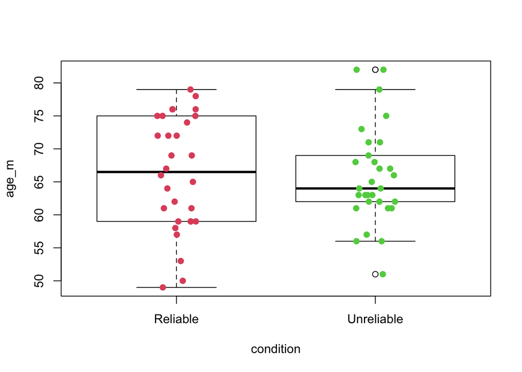

#### Is there a difference in age across conditions in V1 (N=60)?

```
##
##  Welch Two Sample t-test
##
## data:  age_m_cen by condition
## t = 0.2417, df = 56.438, p-value = 0.8099
## alternative hypothesis: true difference in means between group Reliable and group Unreliable is not equal to 0
## 95 percent confidence interval:
##  -3.643424  4.643424
## sample estimates:
##   mean in group Reliable mean in group Unreliable
##                     0.25                    -0.25
```

We find no significant difference in age between reliable and unreliable help conditions.

#### Logistic regression with age-by-condition interaction + 95% confidence intervals in V1 (N=60)

```
##
## Call:
## glm(formula = puzzle_harder ~ condition + age_m_cen + condition *
##     age_m_cen, family = "binomial", data = eals1_v1_n60_df)
##
## Deviance Residuals:
##     Min       1Q   Median       3Q      Max
## -2.2247  -0.8763   0.5779   0.9301   1.5335
##
## Coefficients:
##                               Estimate Std. Error z value Pr(>|z|)
## (Intercept)                    1.06228    0.43447   2.445   0.0145 *
## conditionUnreliable           -1.12090    0.60860  -1.842   0.0655 .
## age_m_cen                      0.06419    0.05053   1.270   0.2039
## conditionUnreliable:age_m_cen  0.12367    0.09665   1.280   0.2007
## ---
## Signif. codes:  0 '***' 0.001 '**' 0.01 '*' 0.05 '.' 0.1 ' ' 1
##
## (Dispersion parameter for binomial family taken to be 1)
##
##     Null deviance: 80.761  on 59  degrees of freedom
## Residual deviance: 66.235  on 56  degrees of freedom
## AIC: 74.235
##
## Number of Fisher Scoring iterations: 4
```

```
##                               2.5 % 97.5 %
## (Intercept)                    0.26   2.00
## conditionUnreliable           -2.36   0.06
## age_m_cen                     -0.03   0.17
## conditionUnreliable:age_m_cen -0.05   0.34
```

#### Computing Bayes factor on logistic regression with age-by-condition interaction in V1 (N=60)

```
## Call:
## BF.glm(x = eals1_mod_v1_n60_ageint, hypothesis = "conditionUnreliable < 0; conditionUnreliable = 0",
##     complement = FALSE)
##
## Bayesian hypothesis test
## Type: exploratory
## Object: glm
## Parameter: general parameters
## Method: adjusted fractional Bayes factors using Gaussian approximations
##
## Posterior probabilities:
##                               Pr(=0) Pr(<0) Pr(>0)
## (Intercept)                    0.163  0.006  0.831
## conditionUnreliable            0.415  0.566  0.019
## age_m_cen                      0.633  0.037  0.329
## conditionUnreliable:age_m_cen  0.631  0.037  0.332
##
## Bayesian hypothesis test
## Type: confirmatory
## Object: glm
## Parameter: general parameters
## Method: adjusted fractional Bayes factors using Gaussian approximations
##
## Posterior probabilities:
##    Pr(hypothesis|data)
## H1               0.577
## H2               0.423
##
## Evidence matrix (Bayes factors):
##       H1    H2
## H1 1.000 1.362
## H2 0.734 1.000
##
## Specification table:
##    complex= complex> fit=  fit>   BF=   BF>    BF   PHP
## H1    1.000      0.5 1.00 0.967 1.000 1.934 1.934 0.577
## H2    0.085      1.0 0.12 1.000 1.421 1.000 1.421 0.423
##
## Hypotheses:
## H1: conditionUnreliable<0
## H2: conditionUnreliable=0
```

#### Logistic regression with age and condition main effects + 95% confidence intervals in V1 (N=60)

```
##
## Call:
## glm(formula = puzzle_harder ~ condition + age_m_cen, family = "binomial",
##     data = eals1_v1_n60_df)
##
## Deviance Residuals:
##     Min       1Q   Median       3Q      Max
## -1.7595  -0.9694   0.4703   1.0100   1.4761
##
## Coefficients:
##                     Estimate Std. Error z value Pr(>|z|)
## (Intercept)          1.16642    0.46273   2.521   0.0117 *
## conditionUnreliable -1.27214    0.60181  -2.114   0.0345 *
## age_m_cen            0.10868    0.04173   2.605   0.0092 **
## ---
## Signif. codes:  0 '***' 0.001 '**' 0.01 '*' 0.05 '.' 0.1 ' ' 1
##
## (Dispersion parameter for binomial family taken to be 1)
##
##     Null deviance: 80.761  on 59  degrees of freedom
## Residual deviance: 68.095  on 57  degrees of freedom
## AIC: 74.095
##
## Number of Fisher Scoring iterations: 4
```

```
##                     2.5 % 97.5 %
## (Intercept)          0.32   2.16
## conditionUnreliable -2.51  -0.13
## age_m_cen            0.03   0.20
```

#### Computing Bayes factor on logistic regression with age and condition main effects in V1 (N=60)

```
## Call:
## BF.glm(x = eals1_mod_v1_n60_agemain, hypothesis = "conditionUnreliable < 0; conditionUnreliable = 0",
##     complement = FALSE)
##
## Bayesian hypothesis test
## Type: exploratory
## Object: glm
## Parameter: general parameters
## Method: adjusted fractional Bayes factors using Gaussian approximations
##
## Posterior probabilities:
##                     Pr(=0) Pr(<0) Pr(>0)
## (Intercept)          0.139  0.005  0.856
## conditionUnreliable  0.293  0.695  0.012
## age_m_cen            0.115  0.004  0.881
##
## Bayesian hypothesis test
## Type: confirmatory
## Object: glm
## Parameter: general parameters
## Method: adjusted fractional Bayes factors using Gaussian approximations
##
## Posterior probabilities:
##    Pr(hypothesis|data)
## H1               0.703
## H2               0.297
##
## Evidence matrix (Bayes factors):
##       H1   H2
## H1 1.000 2.37
## H2 0.422 1.00
##
## Specification table:
##    complex= complex>  fit=  fit>   BF=   BF>    BF   PHP
## H1    1.000      0.5 1.000 0.983 1.000 1.965 1.965 0.703
## H2    0.086      1.0 0.071 1.000 0.829 1.000 0.829 0.297
##
## Hypotheses:
## H1: conditionUnreliable<0
## H2: conditionUnreliable=0
```

Both main effects of age and condition are significant with interaction removed…BF (H1 of a condition effect) = 2.37

In sum, we do not find a significant interaction although the effect may be there and we are under-powered. We will return to this at the end of the markdown file by pooling across V1 and V2 to look at the age-by-condition interaction over a larger sample.

## Experiment 2 (Puzzles Obscured, N = 60)

Next, we run the preregistered analyses for V2 (puzzles obscured) N=60

#### How many participants chose harder/larger-reward puzzle per condition in V2 (N=60)?

```
## # A tibble: 4 × 3
##   condition  puzzle_harder     n
##   <chr>              <dbl> <int>
## 1 Reliable               0    11
## 2 Reliable               1    19
## 3 Unreliable             0    20
## 4 Unreliable             1    10
```

#### Mean of choice harder/larger-reward puzzle per condition in V2 (N=60)

```
## # A tibble: 2 × 2
##   condition  mean_harder
##   <chr>            <dbl>
## 1 Reliable         0.633
## 2 Unreliable       0.333
```

#### Logistic regression in V2 (N=60)

Here we predicting harder/larger reward puzzle choice with reliable as reference group (so asking if there is a negative effect of unreliable on choice harder puzzle, as prereg)

```
##
## Call:
## glm(formula = puzzle_harder ~ condition, family = "binomial",
##     data = eals1_v2_n60_df)
##
## Deviance Residuals:
##     Min       1Q   Median       3Q      Max
## -1.4165  -0.9005  -0.9005   0.9558   1.4823
##
## Coefficients:
##                     Estimate Std. Error z value Pr(>|z|)
## (Intercept)           0.5465     0.3789   1.443   0.1491
## conditionUnreliable  -1.2397     0.5418  -2.288   0.0221 *
## ---
## Signif. codes:  0 '***' 0.001 '**' 0.01 '*' 0.05 '.' 0.1 ' ' 1
##
## (Dispersion parameter for binomial family taken to be 1)
##
##     Null deviance: 83.111  on 59  degrees of freedom
## Residual deviance: 77.620  on 58  degrees of freedom
## AIC: 81.62
##
## Number of Fisher Scoring iterations: 4
```

```
##         (Intercept) conditionUnreliable
##                0.55               -1.24
```

Next, we will compute the odds ratio for effect of unreliable:

```
##         (Intercept) conditionUnreliable
##                1.73                0.29
```

Compared to the reliable condition, those children in the unreliable condition have ~.29 times odds (harder to conceptualize because fraction) of choosing the harder/larger-reward puzzle. We will reanalyze with unreliable as the reference group so we get more interpretable odds ratio.

#### Logistic regression predicting harder/larger reward puzzle choice - flipped with unreliable as reference group in V2 (N=60)

```
##
## Call:
## glm(formula = puzzle_harder ~ relevel(as.factor(condition), ref = "Unreliable"),
##     family = "binomial", data = eals1_v2_n60_df)
##
## Deviance Residuals:
##     Min       1Q   Median       3Q      Max
## -1.4165  -0.9005  -0.9005   0.9558   1.4823
##
## Coefficients:
##                                                           Estimate Std. Error
## (Intercept)                                                -0.6931     0.3873
## relevel(as.factor(condition), ref = "Unreliable")Reliable   1.2397     0.5418
##                                                           z value Pr(>|z|)
## (Intercept)                                                -1.790   0.0735 .
## relevel(as.factor(condition), ref = "Unreliable")Reliable   2.288   0.0221 *
## ---
## Signif. codes:  0 '***' 0.001 '**' 0.01 '*' 0.05 '.' 0.1 ' ' 1
##
## (Dispersion parameter for binomial family taken to be 1)
##
##     Null deviance: 83.111  on 59  degrees of freedom
## Residual deviance: 77.620  on 58  degrees of freedom
## AIC: 81.62
##
## Number of Fisher Scoring iterations: 4
```

```
##                                               (Intercept)
##                                                      0.50
## relevel(as.factor(condition), ref = "Unreliable")Reliable
##                                                      3.45
```

This shows us the reliable odds ratio:

Compared to unreliable, those children in the reliable condition have 3.45 times higher odds of choosing harder/larger reward puzzle (same thing, so say it this way is easier to understand = ~1/.29)

#### 95% confidence intervals of flipped model in V2 (N=60)

```
##                                                           2.5 % 97.5 %
## (Intercept)                                                0.22   1.04
## relevel(as.factor(condition), ref = "Unreliable")Reliable  1.22  10.35
```

#### Computing Bayes factor for logistic regression in V2 (N=60)

```
## Call:
## BF.glm(x = eals1_mod_v2_n60, hypothesis = "condition < 0; condition = 0",
##     complement = FALSE)
##
## Bayesian hypothesis test
## Type: exploratory
## Object: glm
## Parameter: general parameters
## Method: adjusted fractional Bayes factors using Gaussian approximations
##
## Posterior probabilities:
##                     Pr(=0) Pr(<0) Pr(>0)
## (Intercept)          0.578  0.031  0.391
## conditionUnreliable  0.220  0.771  0.009
##
## Bayesian hypothesis test
## Type: confirmatory
## Object: glm
## Parameter: general parameters
## Method: adjusted fractional Bayes factors using Gaussian approximations
##
## Posterior probabilities:
##    Pr(hypothesis|data)
## H1               0.778
## H2               0.222
##
## Evidence matrix (Bayes factors):
##       H1    H2
## H1 1.000 3.499
## H2 0.286 1.000
##
## Specification table:
##    complex= complex>  fit=  fit>   BF=   BF>    BF   PHP
## H1    1.000      0.5 1.000 0.989 1.000 1.978 1.978 0.778
## H2    0.095      1.0 0.054 1.000 0.565 1.000 0.565 0.222
##
## Hypotheses:
## H1: conditionUnreliable<0
## H2: conditionUnreliable=0
```

The data are 3.5 times more likely under the hypothesis of a negative effect of unreliable (H1) than an absence of an effect (H0) on choice of harder/larger-reward puzzle.

#### Let’s look at the age distribution across conditions in V2 (N=60):

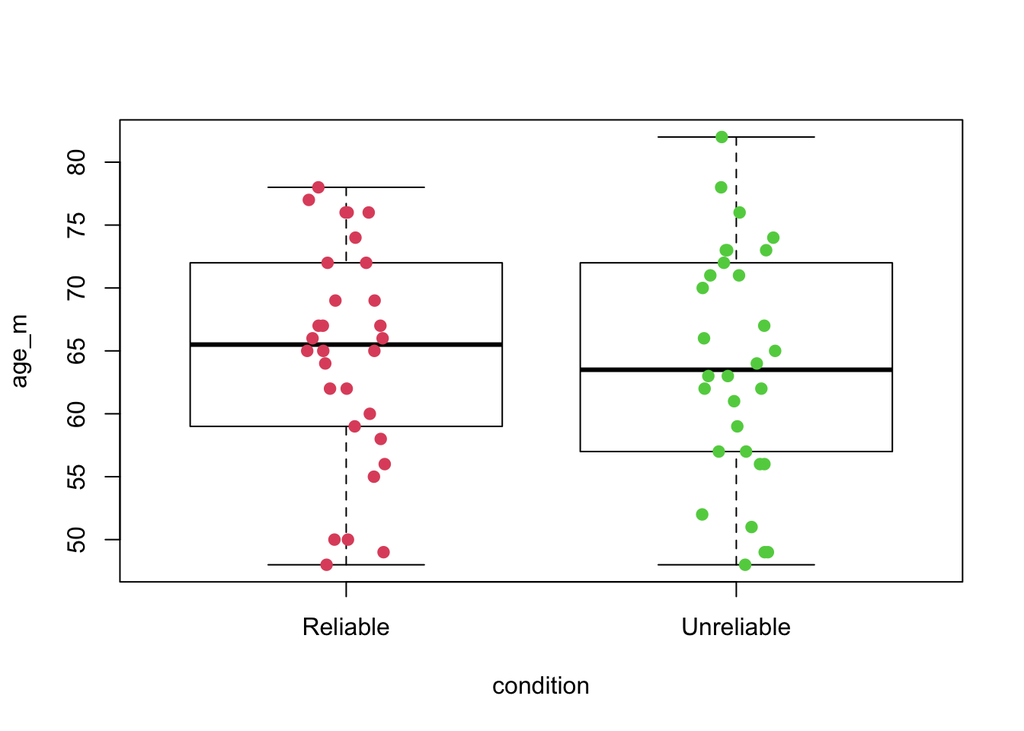

#### Is there a difference in age across conditions in V2 (N=60)?

```
##
##  Welch Two Sample t-test
##
## data:  age_m_cen by condition
## t = 0.2865, df = 57.757, p-value = 0.7755
## alternative hypothesis: true difference in means between group Reliable and group Unreliable is not equal to 0
## 95 percent confidence interval:
##  -3.991588  5.324921
## sample estimates:
##   mean in group Reliable mean in group Unreliable
##                0.3333333               -0.3333333
```

We find no difference between conditions in age for V2. Let’s look at the age-by-condition interaction in this sample.

#### Logistic regression condition age and condition - interaction + 95% confidence intervals - in V2 (N=60)

```
##
## Call:
## glm(formula = puzzle_harder ~ condition + age_m_cen + condition *
##     age_m_cen, family = "binomial", data = eals1_v2_n60_df)
##
## Deviance Residuals:
##     Min       1Q   Median       3Q      Max
## -2.0585  -0.7990  -0.3590   0.8661   2.1197
##
## Coefficients:
##                               Estimate Std. Error z value Pr(>|z|)
## (Intercept)                    0.67277    0.46392   1.450   0.1470
## conditionUnreliable           -1.50875    0.64751  -2.330   0.0198 *
## age_m_cen                      0.17189    0.06686   2.571   0.0101 *
## conditionUnreliable:age_m_cen -0.05351    0.08680  -0.617   0.5375
## ---
## Signif. codes:  0 '***' 0.001 '**' 0.01 '*' 0.05 '.' 0.1 ' ' 1
##
## (Dispersion parameter for binomial family taken to be 1)
##
##     Null deviance: 83.111  on 59  degrees of freedom
## Residual deviance: 61.539  on 56  degrees of freedom
## AIC: 69.539
##
## Number of Fisher Scoring iterations: 4
```

```
##                               2.5 % 97.5 %
## (Intercept)                   -0.20   1.66
## conditionUnreliable           -2.86  -0.29
## age_m_cen                      0.06   0.33
## conditionUnreliable:age_m_cen -0.24   0.12
```

#### Computing Bayes factor on logistic regression with age-by-condition interaction in V2 (N=60)

```
## Call:
## BF.glm(x = eals1_mod_v2_n60_ageint, hypothesis = "conditionUnreliable < 0; conditionUnreliable = 0",
##     complement = FALSE)
##
## Bayesian hypothesis test
## Type: exploratory
## Object: glm
## Parameter: general parameters
## Method: adjusted fractional Bayes factors using Gaussian approximations
##
## Posterior probabilities:
##                               Pr(=0) Pr(<0) Pr(>0)
## (Intercept)                    0.575  0.031  0.394
## conditionUnreliable            0.204  0.788  0.008
## age_m_cen                      0.124  0.004  0.871
## conditionUnreliable:age_m_cen  0.762  0.174  0.064
##
## Bayesian hypothesis test
## Type: confirmatory
## Object: glm
## Parameter: general parameters
## Method: adjusted fractional Bayes factors using Gaussian approximations
##
## Posterior probabilities:
##    Pr(hypothesis|data)
## H1               0.794
## H2               0.206
##
## Evidence matrix (Bayes factors):
##       H1   H2
## H1 1.000 3.86
## H2 0.259 1.00
##
## Specification table:
##    complex= complex>  fit= fit>   BF=  BF>    BF   PHP
## H1     1.00      0.5 1.000 0.99 1.000 1.98 1.980 0.794
## H2     0.08      1.0 0.041 1.00 0.513 1.00 0.513 0.206
##
## Hypotheses:
## H1: conditionUnreliable<0
## H2: conditionUnreliable=0
```

Again, we find the interaction term is not significant. The BF for a negative effect of unreliable condition on choice of puzzle harder is 3.86 in the model with age-by-condition interaction included. We’ll look at the main effects of age and condition next.

#### Logistic regression condition age and condition - main effects + 95% confidence intervals - in V2 (N=60)

```
##
## Call:
## glm(formula = puzzle_harder ~ condition + age_m_cen, family = "binomial",
##     data = eals1_v2_n60_df)
##
## Deviance Residuals:
##     Min       1Q   Median       3Q      Max
## -1.9474  -0.7723  -0.2877   0.8773   1.9309
##
## Coefficients:
##                     Estimate Std. Error z value Pr(>|z|)
## (Intercept)          0.63811    0.43951   1.452 0.146541
## conditionUnreliable -1.54114    0.64751  -2.380 0.017308 *
## age_m_cen            0.14289    0.04257   3.357 0.000789 ***
## ---
## Signif. codes:  0 '***' 0.001 '**' 0.01 '*' 0.05 '.' 0.1 ' ' 1
##
## (Dispersion parameter for binomial family taken to be 1)
##
##     Null deviance: 83.111  on 59  degrees of freedom
## Residual deviance: 61.927  on 57  degrees of freedom
## AIC: 67.927
##
## Number of Fisher Scoring iterations: 4
```

```
##                     2.5 % 97.5 %
## (Intercept)         -0.20   1.55
## conditionUnreliable -2.90  -0.32
## age_m_cen            0.07   0.24
```

#### Computing Bayes factor on logistic regression with age and condition main effects in V2 (N=60)

```
## Call:
## BF.glm(x = eals1_mod_v2_n60_agemain, hypothesis = "conditionUnreliable < 0; conditionUnreliable = 0",
##     complement = FALSE)
##
## Bayesian hypothesis test
## Type: exploratory
## Object: glm
## Parameter: general parameters
## Method: adjusted fractional Bayes factors using Gaussian approximations
##
## Posterior probabilities:
##                     Pr(=0) Pr(<0) Pr(>0)
## (Intercept)          0.574  0.031  0.394
## conditionUnreliable  0.186  0.807  0.007
## age_m_cen            0.014  0.000  0.986
##
## Bayesian hypothesis test
## Type: confirmatory
## Object: glm
## Parameter: general parameters
## Method: adjusted fractional Bayes factors using Gaussian approximations
##
## Posterior probabilities:
##    Pr(hypothesis|data)
## H1               0.813
## H2               0.187
##
## Evidence matrix (Bayes factors):
##      H1    H2
## H1 1.00 4.348
## H2 0.23 1.000
##
## Specification table:
##    complex= complex>  fit=  fit>   BF=   BF>    BF   PHP
## H1     1.00      0.5 1.000 0.991 1.000 1.983 1.983 0.813
## H2     0.08      1.0 0.036 1.000 0.456 1.000 0.456 0.187
##
## Hypotheses:
## H1: conditionUnreliable<0
## H2: conditionUnreliable=0
```

Both main effects of age and condition are significant with interaction removed…BF (H1 of a condition effect) = 4.35.

In sum, we do not find a significant interaction although we find main effects of condition and age. We will look at the pooled results across V1 and V2 in case we’re under-powered to find the age-by-condition interaction.

## Pooled Results (Puzzles Visible + Obscured, N = 120)

So, let’s look at the pooled results across study 1 and 2

#### How many participants chose harder/larger-reward puzzle per condition in pooled data (N=120)?

```
## # A tibble: 4 × 3
## # Groups:   condition [2]
##   condition  puzzle_harder count
##   <chr>              <dbl> <int>
## 1 Reliable               0    19
## 2 Reliable               1    41
## 3 Unreliable             0    36
## 4 Unreliable             1    24
```

Here we predicting harder/larger reward puzzle choice with reliable as reference group (so asking if there is a negative effect of unreliable on choice harder puzzle). We’ll also add experiment V1/V2 as a fixed effect.

```
##
## Call:
## glm(formula = puzzle_harder ~ condition + experiment, family = "binomial",
##     data = eals1_pooled_n120_df)
##
## Deviance Residuals:
##     Min       1Q   Median       3Q      Max
## -1.6381  -1.1124   0.7784   0.9645   1.4717
##
## Coefficients:
##                     Estimate Std. Error z value Pr(>|z|)
## (Intercept)           1.5535     0.6598   2.355  0.01854 *
## conditionUnreliable  -1.1934     0.3866  -3.087  0.00202 **
## experiment           -0.5148     0.3862  -1.333  0.18252
## ---
## Signif. codes:  0 '***' 0.001 '**' 0.01 '*' 0.05 '.' 0.1 ' ' 1
##
## (Dispersion parameter for binomial family taken to be 1)
##
##     Null deviance: 165.52  on 119  degrees of freedom
## Residual deviance: 153.89  on 117  degrees of freedom
## AIC: 159.89
##
## Number of Fisher Scoring iterations: 4
```

```
##         (Intercept) conditionUnreliable          experiment
##                1.55               -1.19               -0.51
```

Next, we will compute the odds ratio for effect of unreliable:

```
##         (Intercept) conditionUnreliable          experiment
##                4.73                0.30                0.60
```

Compared to the reliable condition, those children in the unreliable condition have ~.30 times odds (harder to conceptualize because fraction) of choosing the harder/larger-reward puzzle. We will reanalyze with unreliable as the reference group so we get more interpretable odds ratio. Those in experiment V2 have ~ .60 times odds of choosing harder/puzzle. Although experiment is not a significant predictor, note this direction makes sense if fewer participants choose the harder puzzle when it was obscured.

#### Logistic regression predicting harder/larger reward puzzle choice - flipped with unreliable/experiment V2 as reference group in pooled (N=120)

```
##
## Call:
## glm(formula = puzzle_harder ~ relevel(as.factor(condition), ref = "Unreliable") +
##     relevel(as.factor(experiment), ref = "2"), family = "binomial",
##     data = eals1_pooled_n120_df)
##
## Deviance Residuals:
##     Min       1Q   Median       3Q      Max
## -1.6381  -1.1124   0.7784   0.9645   1.4717
##
## Coefficients:
##                                                           Estimate Std. Error
## (Intercept)                                                -0.6695     0.3344
## relevel(as.factor(condition), ref = "Unreliable")Reliable   1.1934     0.3866
## relevel(as.factor(experiment), ref = "2")1                  0.5148     0.3862
##                                                           z value Pr(>|z|)
## (Intercept)                                                -2.002  0.04526 *
## relevel(as.factor(condition), ref = "Unreliable")Reliable   3.087  0.00202 **
## relevel(as.factor(experiment), ref = "2")1                  1.333  0.18252
## ---
## Signif. codes:  0 '***' 0.001 '**' 0.01 '*' 0.05 '.' 0.1 ' ' 1
##
## (Dispersion parameter for binomial family taken to be 1)
##
##     Null deviance: 165.52  on 119  degrees of freedom
## Residual deviance: 153.89  on 117  degrees of freedom
## AIC: 159.89
##
## Number of Fisher Scoring iterations: 4
```

```
##                                               (Intercept)
##                                                      0.51
## relevel(as.factor(condition), ref = "Unreliable")Reliable
##                                                      3.30
##                relevel(as.factor(experiment), ref = "2")1
##                                                      1.67
```

This shows us the reliable odds ratio:

Compared to unreliable, those children in the reliable condition have 3.30 times higher odds of choosing harder/larger reward puzzle (same thing, so say it this way is easier to understand = ~1/.30).

#### 95% confidence intervals of flipped model in pooled (N=120)

```
##                                                           2.5 % 97.5 %
## (Intercept)                                                0.26   0.97
## relevel(as.factor(condition), ref = "Unreliable")Reliable  1.57   7.16
## relevel(as.factor(experiment), ref = "2")1                 0.79   3.61
```

#### Computing Bayes factor for logistic regression in pooled (N=120)

```
## Call:
## BF.glm(x = eals1_mod_pooled_n120, hypothesis = "condition < 0; condition = 0",
##     complement = FALSE)
##
## Bayesian hypothesis test
## Type: exploratory
## Object: glm
## Parameter: general parameters
## Method: adjusted fractional Bayes factors using Gaussian approximations
##
## Posterior probabilities:
##                     Pr(=0) Pr(<0) Pr(>0)
## (Intercept)          0.255  0.007  0.738
## conditionUnreliable  0.045  0.954  0.001
## experiment           0.693  0.279  0.028
##
## Bayesian hypothesis test
## Type: confirmatory
## Object: glm
## Parameter: general parameters
## Method: adjusted fractional Bayes factors using Gaussian approximations
##
## Posterior probabilities:
##    Pr(hypothesis|data)
## H1               0.955
## H2               0.045
##
## Evidence matrix (Bayes factors):
##       H1     H2
## H1 1.000 21.381
## H2 0.047  1.000
##
## Specification table:
##    complex= complex>  fit=  fit>   BF=   BF>    BF   PHP
## H1    1.000      0.5 1.000 0.999 1.000 1.998 1.998 0.955
## H2    0.094      1.0 0.009 1.000 0.093 1.000 0.093 0.045
##
## Hypotheses:
## H1: conditionUnreliable<0
## H2: conditionUnreliable=0
```

As expected, we find a higher BF for our hypothesis (H1) of a negative effect of unreliable on choice of harder/larger-reward puzzle over the null hypothesis (H0) because we doubled our sample size. Here BF (H1) = 21.38.

#### Now looking at age across the pooled data (N=120)

#### Age distribution across experiments v1 and v2 (N=120)

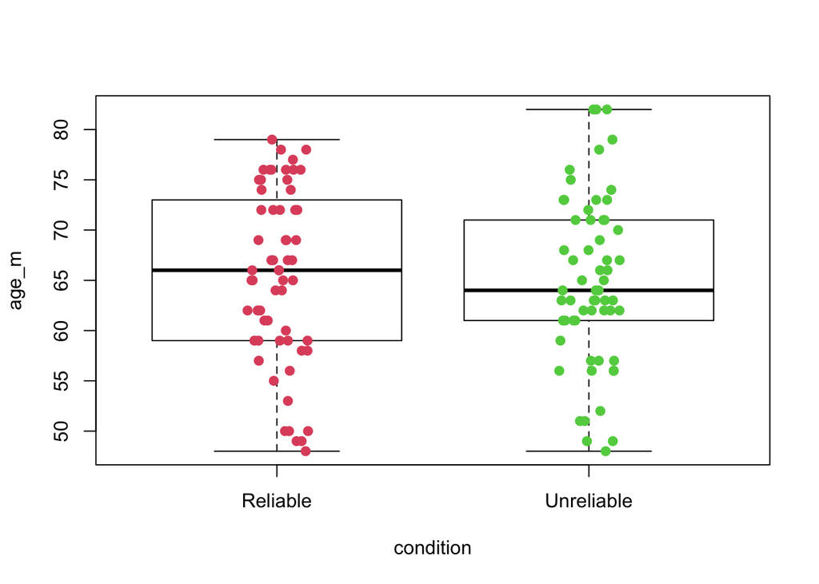

#### Is there a difference in age across conditions (N=120)?

```
##
##  Welch Two Sample t-test
##
## data:  age_m_cen by condition
## t = 0.3761, df = 117.85, p-value = 0.7075
## alternative hypothesis: true difference in means between group Reliable and group Unreliable is not equal to 0
## 95 percent confidence interval:
##  -2.488102  3.654769
## sample estimates:
##   mean in group Reliable mean in group Unreliable
##                0.2916667               -0.2916667
```

We find no difference in age by condition in the pooled dataset.

Next, we ask if we find a significant interaction of age-by-condition on choice of harder puzzle in the pooled data:

#### Logistic regression - interaction age by condition with experiment as fixed effect (N=120)

```
##
## Call:
## glm(formula = puzzle_harder ~ condition + age_m_cen + experiment +
##     condition * age_m_cen, family = "binomial", data = eals1_pooled_n120_df)
##
## Deviance Residuals:
##     Min       1Q   Median       3Q      Max
## -1.9467  -0.8822   0.4371   0.9270   1.8958
##
## Coefficients:
##                               Estimate Std. Error z value Pr(>|z|)
## (Intercept)                    1.62309    0.73825   2.199  0.02791 *
## conditionUnreliable           -1.38637    0.43968  -3.153  0.00162 **
## age_m_cen                      0.11250    0.03914   2.874  0.00405 **
## experiment                    -0.48560    0.43103  -1.127  0.25990
## conditionUnreliable:age_m_cen  0.03061    0.05995   0.511  0.60969
## ---
## Signif. codes:  0 '***' 0.001 '**' 0.01 '*' 0.05 '.' 0.1 ' ' 1
##
## (Dispersion parameter for binomial family taken to be 1)
##
##     Null deviance: 165.52  on 119  degrees of freedom
## Residual deviance: 130.12  on 115  degrees of freedom
## AIC: 140.12
##
## Number of Fisher Scoring iterations: 4
```

```
##                               2.5 % 97.5 %
## (Intercept)                    0.22   3.13
## conditionUnreliable           -2.28  -0.55
## age_m_cen                      0.04   0.20
## experiment                    -1.35   0.35
## conditionUnreliable:age_m_cen -0.09   0.15
```

Here, we find the interaction of age-by-condition is not a significant predictor of puzzle choice in the pooled data. Age and unreliable condition remain significant predictors.

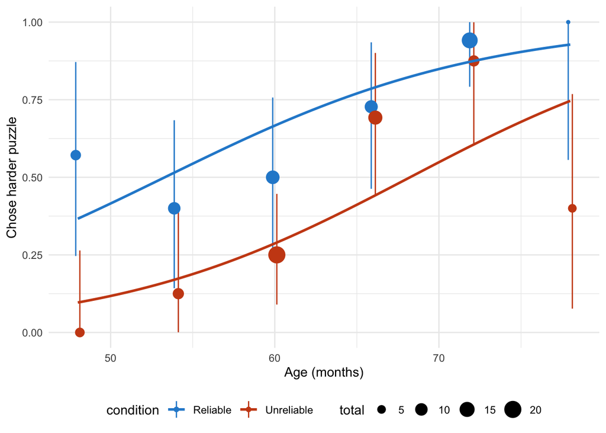

Finally, we will visualize the proportion choice harder/easier puzzle in stacked bar chart

[figure not shown]